# CRDialogue

An exploration of the dialogue from Critical Role

### Does Liam play the saddest bois? A word sentiment analysis of cast dialoge

Liam has a reputation for playing sad characters, but is this deserved? Does his dialogue contain more sad words than the rest of the cast?

To answer this I searched the dialogue from the show for words associated with a sad sentiment, and words associated with joy as a control. I then calculated the ratio of joyful to sad words for each cast member and plotted it.

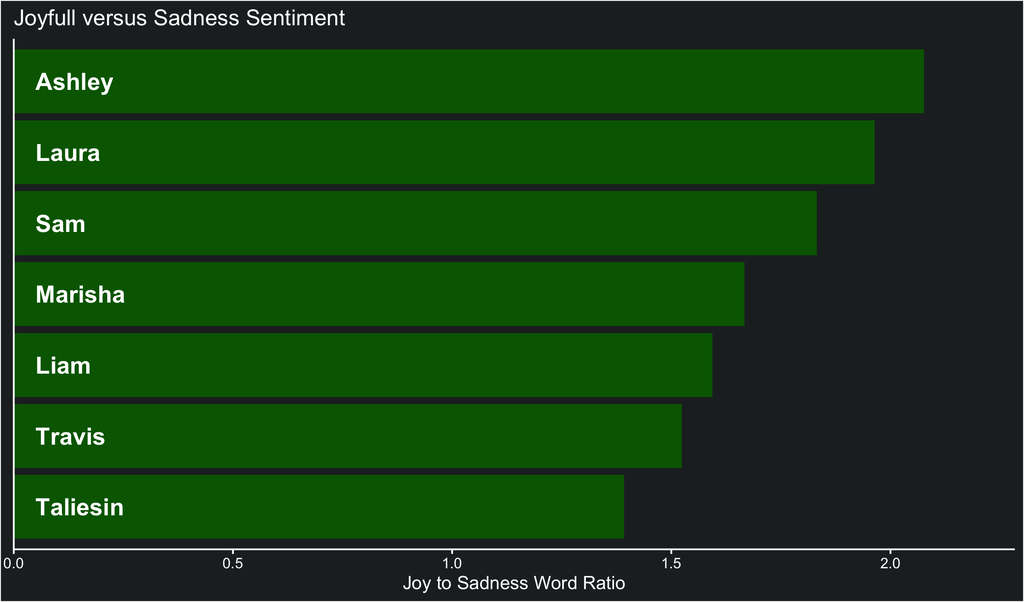

joyful vs sad

| Name | Joy | Sadness | Ratio |
| --- | --- | --- | --- |
| Ashley | 3168 | 1526 | 2.08 |
| Laura | 14341 | 7304 | 1.96 |
| Sam | 13199 | 7207 | 1.83 |
| Marisha | 10873 | 6522 | 1.67 |
| Liam | 9718 | 6099 | 1.59 |
| Travis | 10335 | 6783 | 1.52 |
| Taliesin | 10754 | 7724 | 1.39 |

We can see that while Liam is in the bottom half, both Travis and Taliesin have lower scores.

I also wanted to take a slightly different approach and look at for words with either a positive or negative sentiment.

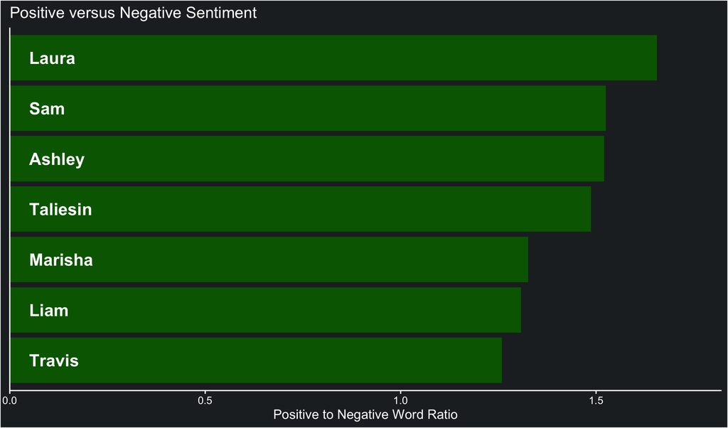

positive vs negative

| Name | Negative | Positive | Ratio |
| --- | --- | --- | --- |
| Laura | 18281 | 30260 | 1.66 |
| Sam | 16287 | 24839 | 1.53 |
| Ashley | 4100 | 6234 | 1.52 |
| Taliesin | 15411 | 22912 | 1.49 |
| Marisha | 17907 | 23743 | 1.33 |
| Liam | 15753 | 20601 | 1.31 |
| Travis | 17945 | 22596 | 1.26 |

Again Liam is near the bottom, but Travis still has a lower score.

### Acknowledgments

The data come from the [Critical Role Linkable transcripts](https://kryogenix.org/crsearch/). Last updated with data from campaign 2 episode 120.

Huge thanks to the cast and crew of Critical Role.